# GGPLOT2

### Adicionando layers

De maneira geral, a sintaxe que vamos usar é `{r} geom_yyy(data = dados, aes(x = x, y = y))`, sendo “line” para linhas, “point” para pontos e assim por diante.

Por exemplo, para criar um plot de peso x altura temos

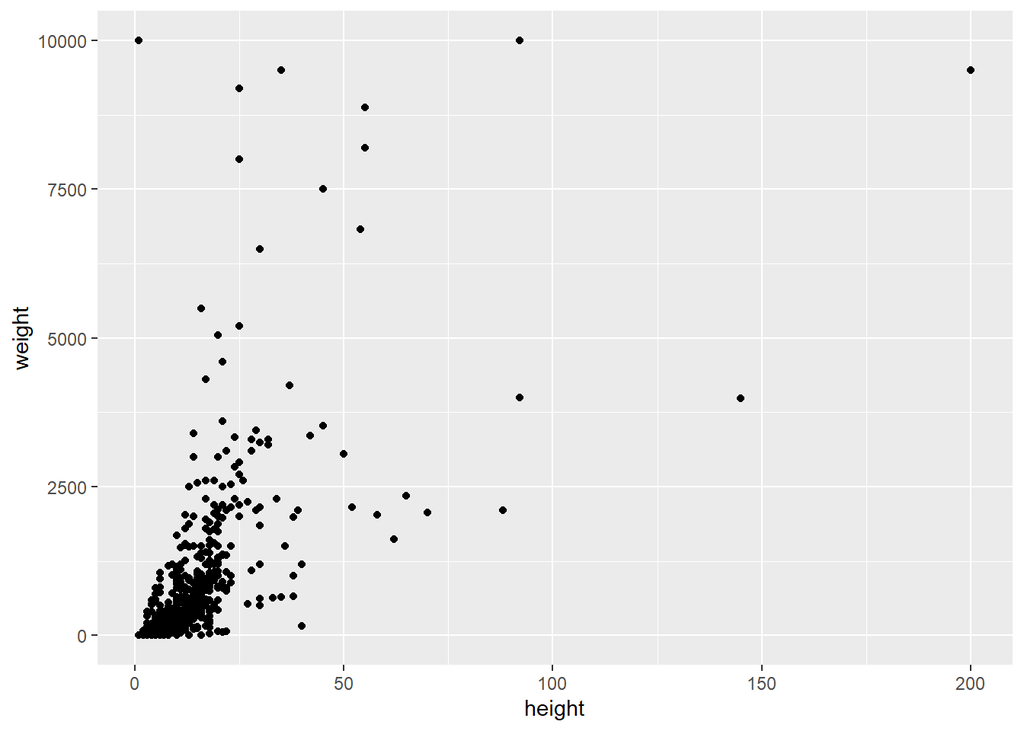

```r
ggplot()+
  geom_point(data = dados, aes(x = height, y = weight))
```

Se quisermos que os pontos tenham uma cor em particular, usamos

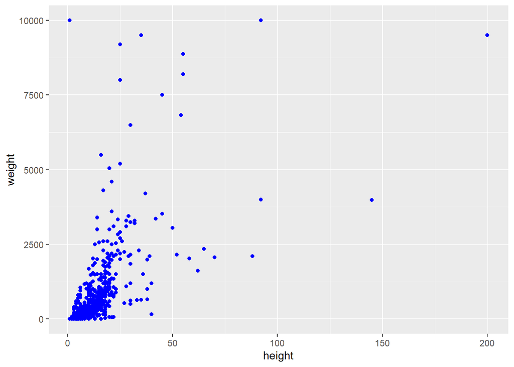

```r
ggplot()+
  geom_point(data = dados, aes(x = height, y = weight), color = "blue")
```

Se quisermos que a cor seja dependente de uma variável, por exemplo o tipo, precisamos colocar ela dentro do “aesthesic”.

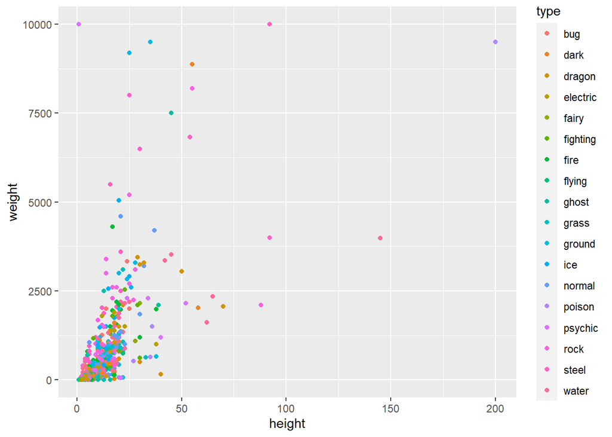

```r
ggplot()+
  geom_point(data = dados, aes(x = height, y = weight, color = type))
```

Note que o ggplot2 funciona em um esquema de “linha por linha”. Ou seja, os dados devem estar em formato “long table”.

## Cores, Formas e Eixos

É possível alterar as cores dos gráficos, por exemplo usando escalas pré-programadas

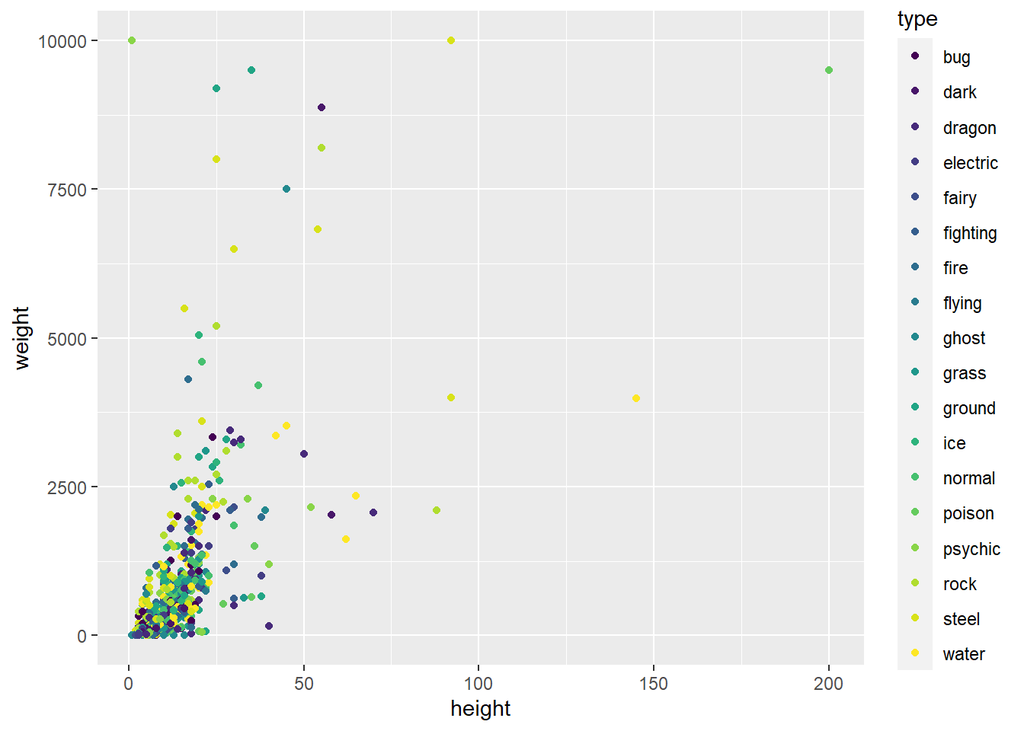

```r
ggplot()+
  geom_point(data = dados, aes(x = height, y = weight, color = type))+
  scale_color_viridis_d() #d -> quer dizer "discrete"
```

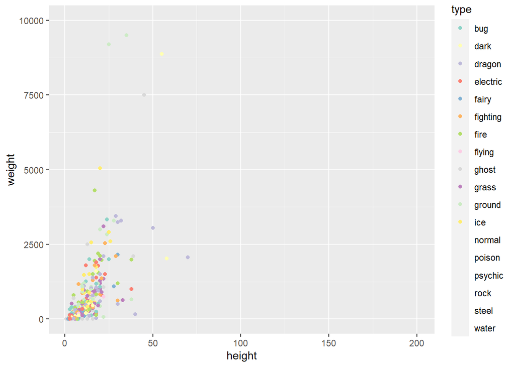

```r
ggplot()+
  geom_point(data = dados, aes(x = height, y = weight, color = type))+
  scale_color_brewer(palette = "Set3") #d -> quer dizer "discrete"
```

Ou até mesmo passando as cores que querem usar. Vamos criar a coluna tamnho, como antes, mudando um pouco os breaks

```r
dados <- dados %>%
  dplyr::mutate(
    tamanho = dplyr::case_when(
            height < 5 ~ "baixinho",
            height < 50 ~ "pequeno",
            height < 100 ~ "médio",
            TRUE ~ "altão"
        )
  )
```

Criar o plot com cores em função de “tamanho”

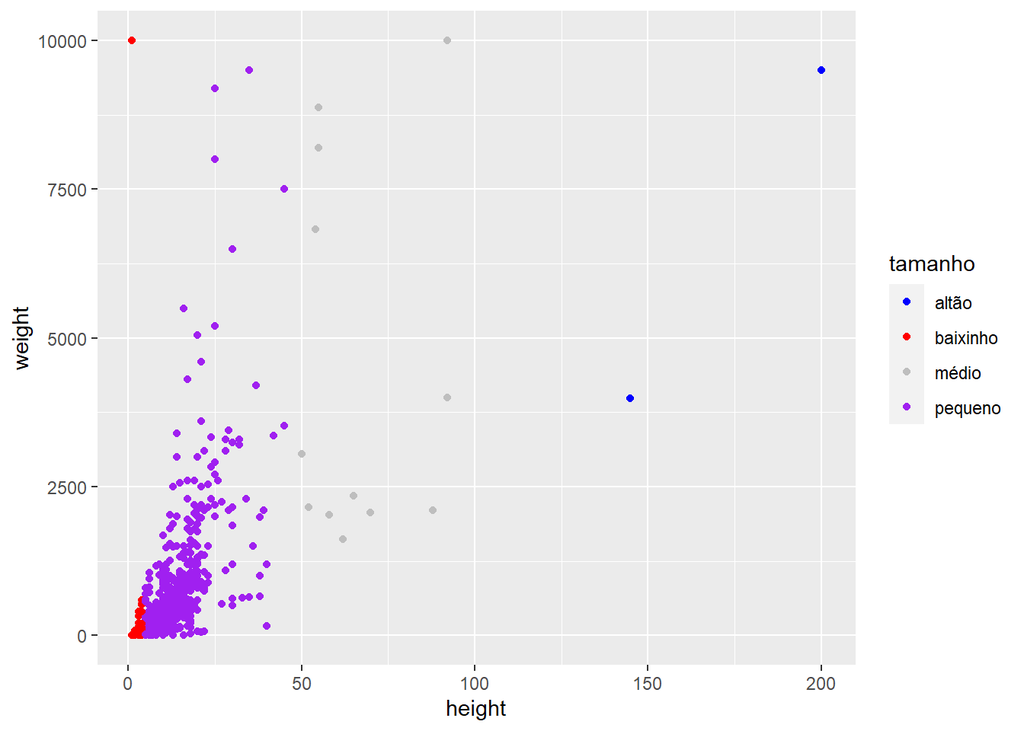

```r
dados <- dados %>%
  dplyr::mutate(
    tamanho = dplyr::case_when(
            height < 5 ~ "baixinho",
            height < 50 ~ "pequeno",
            height < 100 ~ "médio",
            TRUE ~ "altão"
        )
  )

ggplot()+
  geom_point(data = dados, aes(x = height, y = weight, color = tamanho))+
  scale_color_manual(values = c("blue", "red", "grey", "purple"))
```

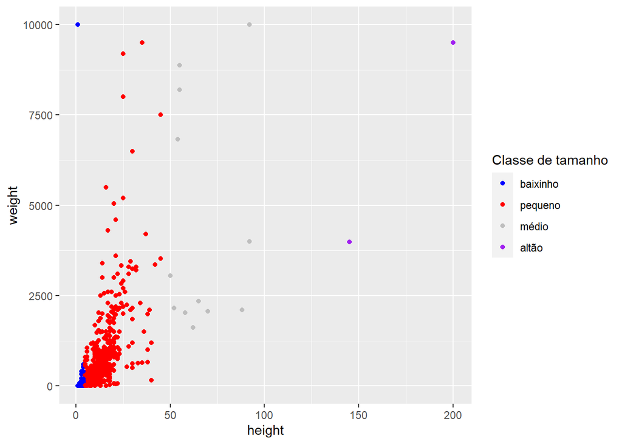

```r
# notem que os breaks estão estranhos
ggplot()+
  geom_point(data = dados, aes(x = height, y = weight, color = tamanho))+
  scale_color_manual(values = c("blue", "red", "grey", "purple"), breaks = c("baixinho", "pequeno", "médio", "altão"), name = "Classe de tamanho")
```

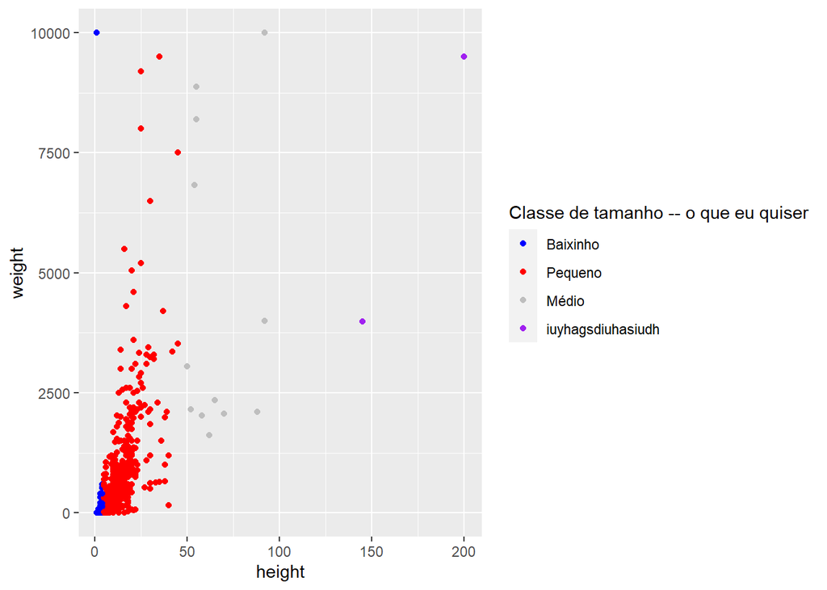

```r
# notem que os breaks estão estranhos
ggplot()+
  geom_point(data = dados, aes(x = height, y = weight, color = tamanho))+
  scale_color_manual(values = c("blue", "red", "grey", "purple"), breaks = c("baixinho", "pequeno", "médio", "altão"),
                     label = c("Baixinho", "Pequeno", "Médio", "iuyhagsdiuhasiudh"), name = "Classe de tamanho -- o que eu quiser")
```

Agora vamos adicionar uma forma diferente

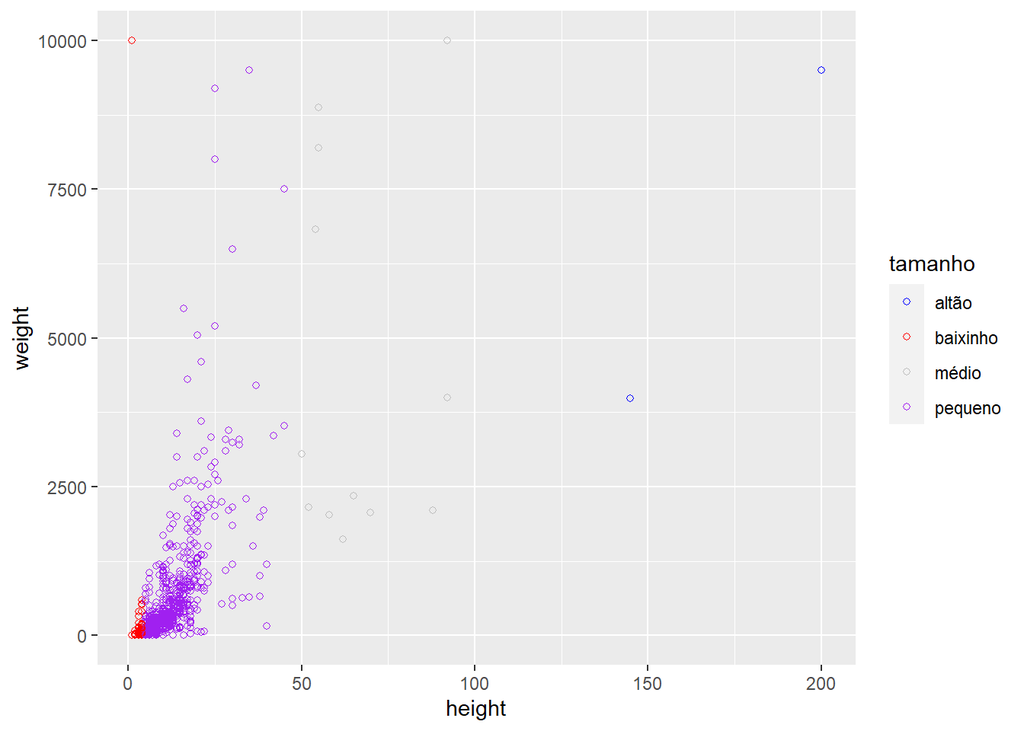

```r
ggplot()+
  geom_point(data = dados, aes(x = height, y = weight, color = tamanho), shape = 21)+
  scale_color_manual(values = c("blue", "red", "grey", "purple"))
```

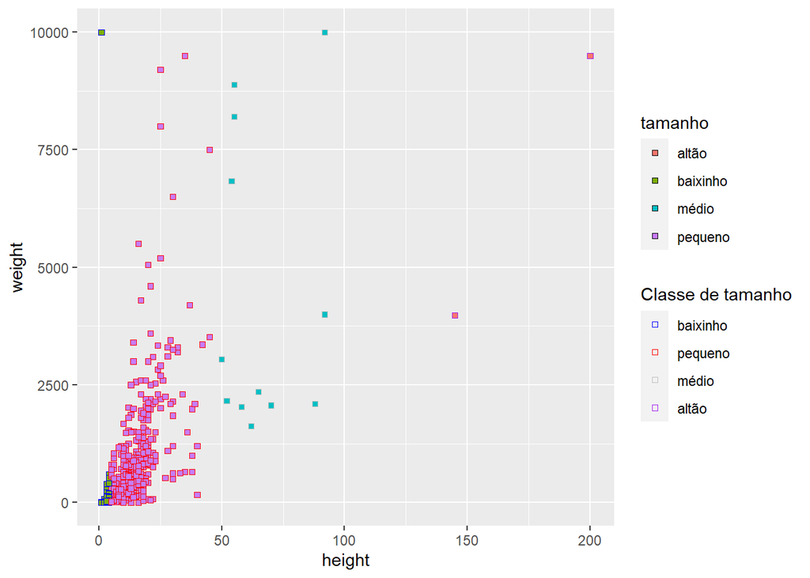

```r
# estranho
ggplot()+
  geom_point(data = dados, aes(x = height, y = weight, color = tamanho, fill = tamanho), shape = 22)+
  scale_color_manual(values = c("blue", "red", "grey", "purple"), breaks = c("baixinho", "pequeno", "médio", "altão"), name = "Classe de tamanho")
```

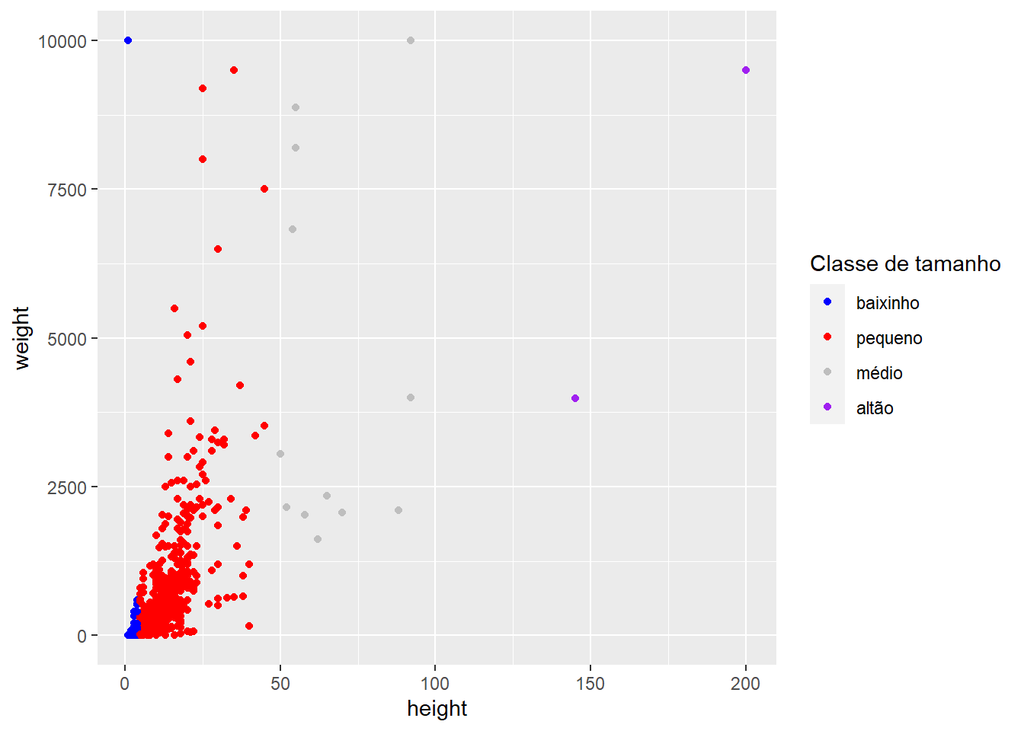

```r
ggplot()+
  geom_point(data = dados, aes(x = height, y = weight, color = tamanho, fill = tamanho), shape = 21)+
  scale_color_manual(values = c("blue", "red", "grey", "purple"), breaks = c("baixinho", "pequeno", "médio", "altão"), name = "Classe de tamanho")+
  scale_fill_manual(values = c("blue", "red", "grey", "purple"), breaks = c("baixinho", "pequeno", "médio", "altão"), name = "Classe de tamanho")
```

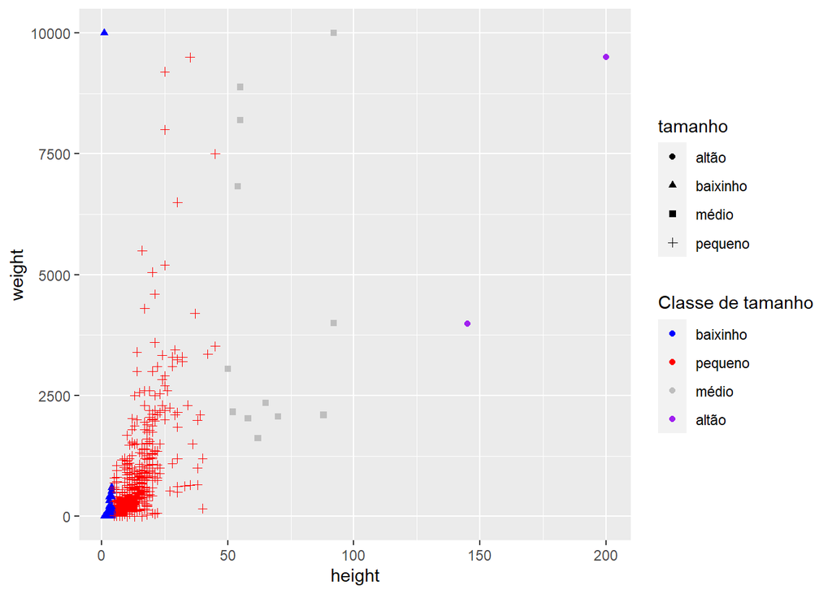

```r
#estranho
ggplot()+
  geom_point(data = dados, aes(x = height, y = weight, color = tamanho, fill = tamanho, shape = tamanho))+
  scale_color_manual(values = c("blue", "red", "grey", "purple"), breaks = c("baixinho", "pequeno", "médio", "altão"), name = "Classe de tamanho")+
  scale_fill_manual(values = c("blue", "red", "grey", "purple"), breaks = c("baixinho", "pequeno", "médio", "altão"), name = "Classe de tamanho")
```

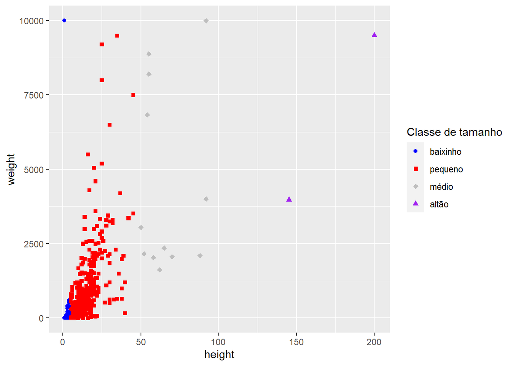

```r
ggplot()+
  geom_point(data = dados, aes(x = height, y = weight, color = tamanho, fill = tamanho, shape = tamanho))+
  scale_color_manual(values = c("blue", "red", "grey", "purple"), breaks = c("baixinho", "pequeno", "médio", "altão"), name = "Classe de tamanho")+
  scale_fill_manual(values = c("blue", "red", "grey", "purple"), breaks = c("baixinho", "pequeno", "médio", "altão"), name = "Classe de tamanho")+
  scale_shape_manual(values = c(21,22,23,24), breaks = c("baixinho", "pequeno", "médio", "altão"), name = "Classe de tamanho")
```

Podemos tambem alterar os eixos gráficos

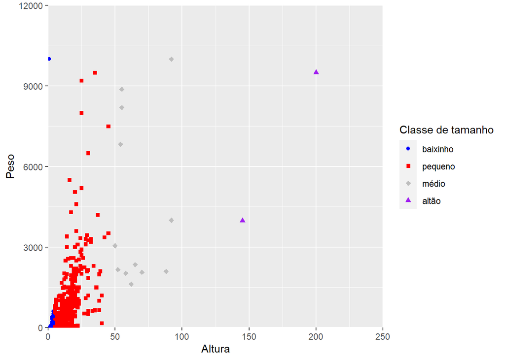

```r
ggplot()+
  geom_point(data = dados, aes(x = height, y = weight, color = tamanho, fill = tamanho, shape = tamanho))+
  scale_color_manual(values = c("blue", "red", "grey", "purple"), breaks = c("baixinho", "pequeno", "médio", "altão"), name = "Classe de tamanho")+
  scale_fill_manual(values = c("blue", "red", "grey", "purple"), breaks = c("baixinho", "pequeno", "médio", "altão"), name = "Classe de tamanho")+
  scale_shape_manual(values = c(21,22,23,24), breaks = c("baixinho", "pequeno", "médio", "altão"), name = "Classe de tamanho")+
  scale_y_continuous(limits = c(0, 12000), expand = c(0,0), name = "Peso")+
  scale_x_continuous(limits = c(0, 250), expand = c(0,0), name = "Altura")
```

```r
#expand = c(0,0) "cola" o inicio dos eixos nos limites
```

## Temas

o ggplot2 tem uma biblioteca de temas. Alguns deles são default, dêem uma olhada [aqui](https://wilsonfreitas.github.io/posts/temas-do-ggplot.html).

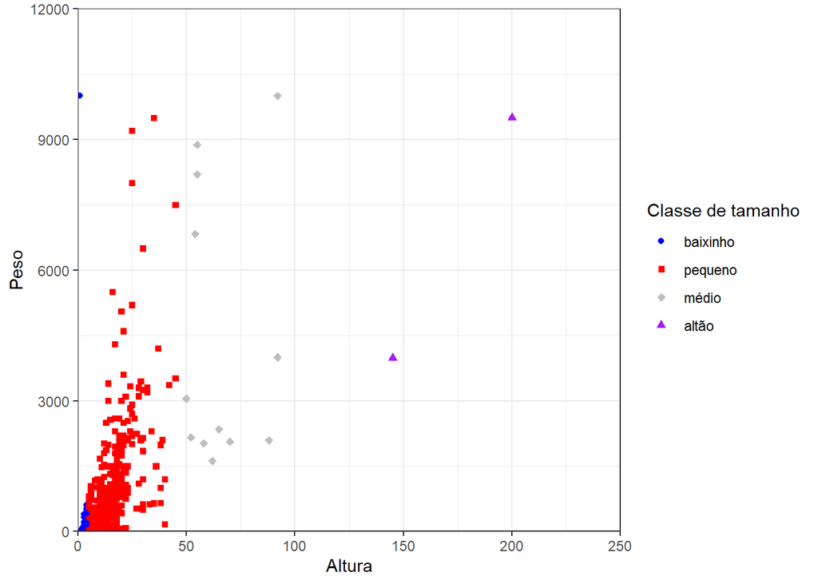

```r
ggplot()+
  geom_point(data = dados, aes(x = height, y = weight, color = tamanho, fill = tamanho, shape = tamanho))+
  scale_color_manual(values = c("blue", "red", "grey", "purple"), breaks = c("baixinho", "pequeno", "médio", "altão"), name = "Classe de tamanho")+
  scale_fill_manual(values = c("blue", "red", "grey", "purple"), breaks = c("baixinho", "pequeno", "médio", "altão"), name = "Classe de tamanho")+
  scale_shape_manual(values = c(21,22,23,24), breaks = c("baixinho", "pequeno", "médio", "altão"), name = "Classe de tamanho")+
  scale_y_continuous(limits = c(0, 12000), expand = c(0,0), name = "Peso")+
  scale_x_continuous(limits = c(0, 250), expand = c(0,0), name = "Altura")+
  theme_bw()
```

Também existe uma biblioteca extra para isso. Chequem esse [link](https://statisticsglobe.com/ggthemes-package-r)

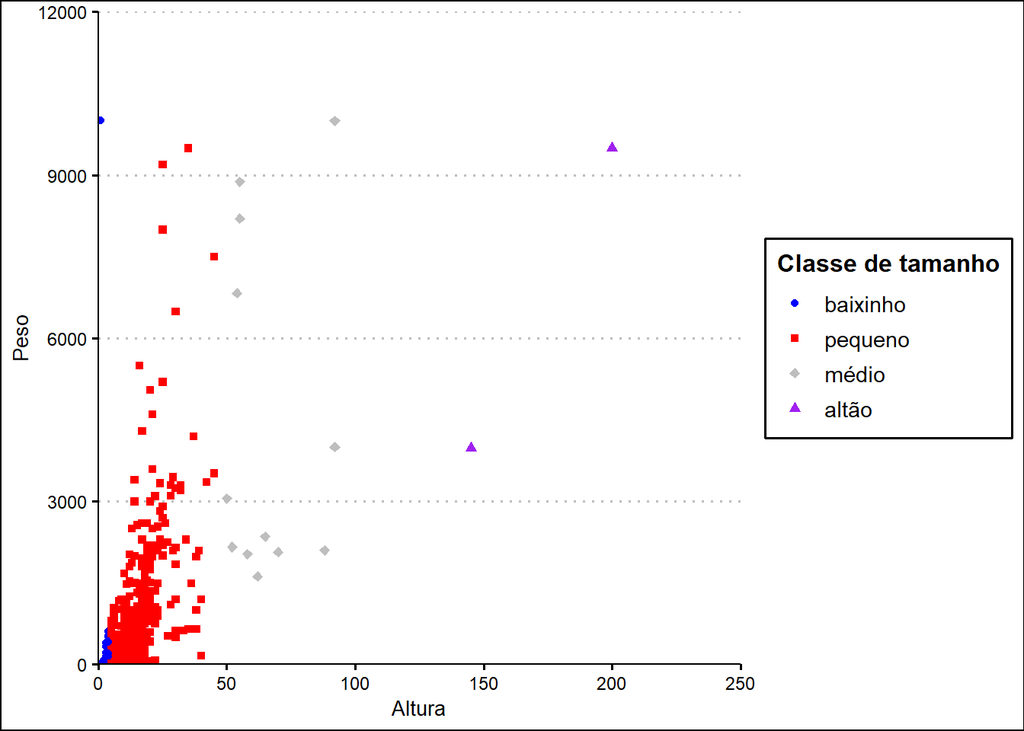

```r
library(ggthemes)

ggplot()+
  geom_point(data = dados, aes(x = height, y = weight, color = tamanho, fill = tamanho, shape = tamanho))+
  scale_color_manual(values = c("blue", "red", "grey", "purple"), breaks = c("baixinho", "pequeno", "médio", "altão"), name = "Classe de tamanho")+
  scale_fill_manual(values = c("blue", "red", "grey", "purple"), breaks = c("baixinho", "pequeno", "médio", "altão"), name = "Classe de tamanho")+
  scale_shape_manual(values = c(21,22,23,24), breaks = c("baixinho", "pequeno", "médio", "altão"), name = "Classe de tamanho")+
  scale_y_continuous(limits = c(0, 12000), expand = c(0,0), name = "Peso")+
  scale_x_continuous(limits = c(0, 250), expand = c(0,0), name = "Altura")+
  theme_clean()
```

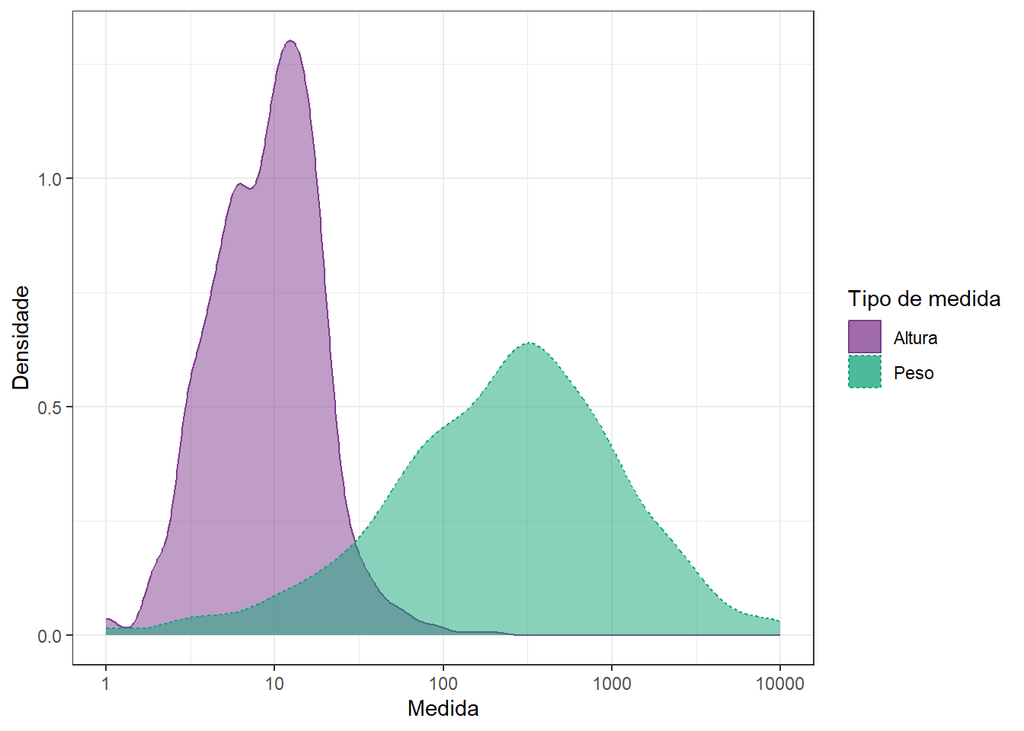

```r
library(rcartocolor)

cores <- carto_pal(3,name="Bold")

ggplot()+
  geom_density(data = dados, aes(x = height, color="Altura", linetype="Altura", fill="Altura"), alpha=0.5)+
  geom_density(data = dados, aes(x = weight, color="Peso", linetype="Peso", fill="Peso"), alpha=0.5)+
  scale_x_continuous(trans='log10')+
  labs(x="Medida", y="Densidade", color="Tipo de medida", linetype="Tipo de medida", fill="Tipo de medida")+
  scale_color_manual(values=cores[1:2])+
  scale_fill_manual(values=cores[1:2])+
  theme_bw()
```

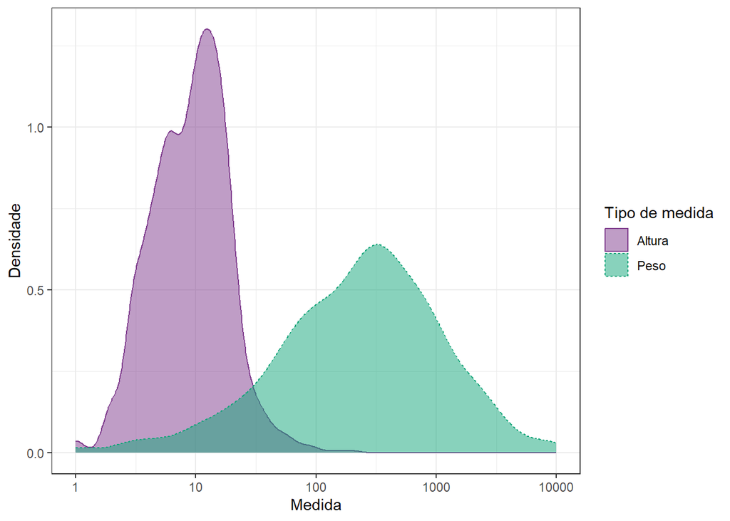

```r
dados %>%
  select(Peso = weight, Altura = height) %>%
  tidyr::pivot_longer(cols = c(1,2), values_to = "Medida", names_to = "Tipo de medida") %>%
  ggplot()+
  geom_density(aes(x = Medida, color = `Tipo de medida`, linetype = `Tipo de medida`, fill = `Tipo de medida`), alpha = 0.5)+
  scale_x_continuous(trans = 'log10')+
  scale_color_manual(values = cores[1:2])+
  scale_fill_manual(values = cores[1:2])+
  labs(x = "Medida", y = "Densidade", color = "Tipo de medida", linetype = "Tipo de medida", fill = "Tipo de medida")+
  theme_bw()
```

## Adicionando temas sobre temas

É possível adicionar uma camada de tema customizada que vai “sobrepor” o padrão

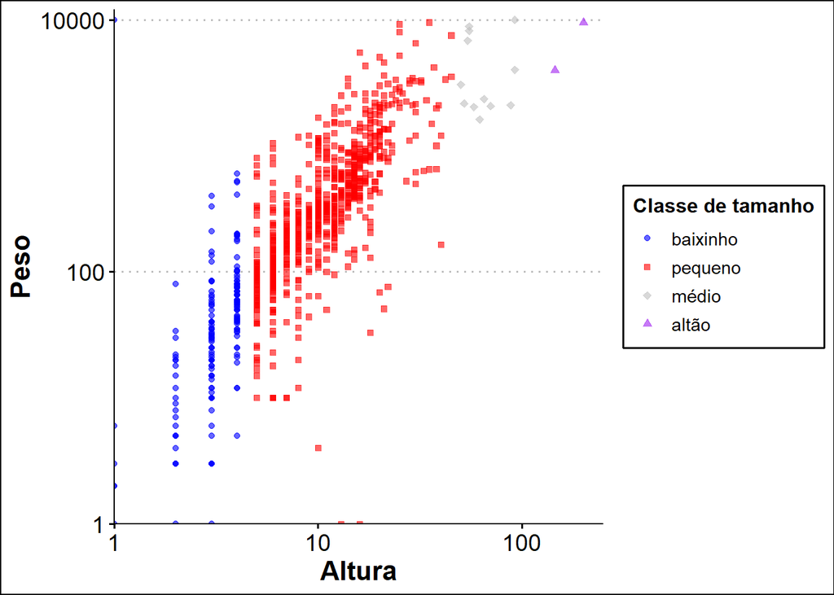

```r
library(ggthemes)

ggplot()+
  geom_point(data = dados, aes(x = height, y = weight, color = tamanho, fill = tamanho, shape = tamanho), alpha = 0.6)+
  scale_color_manual(values = c("blue", "red", "grey", "purple"), breaks = c("baixinho", "pequeno", "médio", "altão"), name = "Classe de tamanho")+
  scale_fill_manual(values = c("blue", "red", "grey", "purple"), breaks = c("baixinho", "pequeno", "médio", "altão"), name = "Classe de tamanho")+
  scale_shape_manual(values = c(21,22,23,24), breaks = c("baixinho", "pequeno", "médio", "altão"), name = "Classe de tamanho")+
  scale_y_continuous(trans = "log10", limits = c(1, 12000), expand = c(0,0), name = "Peso")+
  scale_x_continuous(trans = "log10", limits = c(1, 250), expand = c(0,0), name = "Altura")+
  theme_clean()+
  theme(
    axis.title = element_text(size = 16, face = "bold"),
    axis.text = element_text(size = 14)
  )
```

## Gráficos de barras

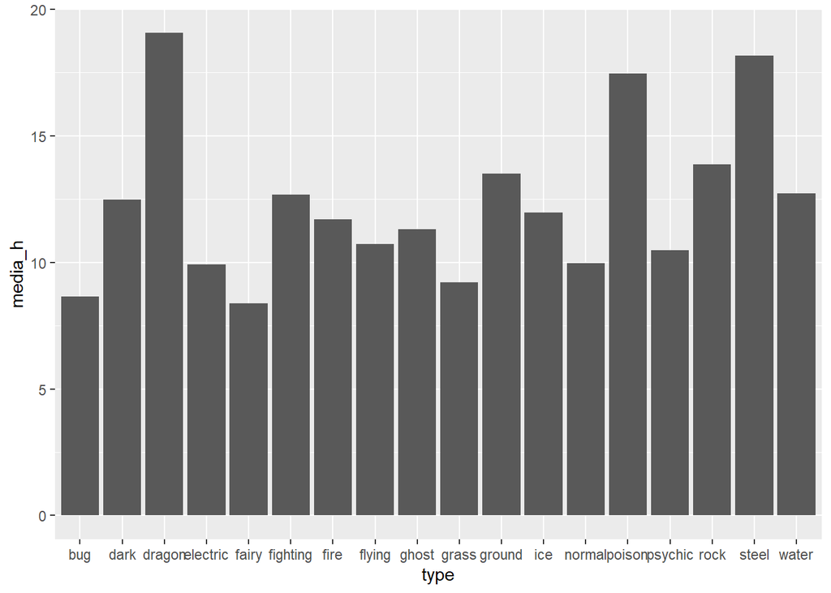

```r
dados %>%
  group_by(type) %>%
  summarise(
    media_h = mean(height),
    media_w = mean(weight)
  ) %>%
  ggplot()+
    geom_col(aes(x = type, y = media_h))
```

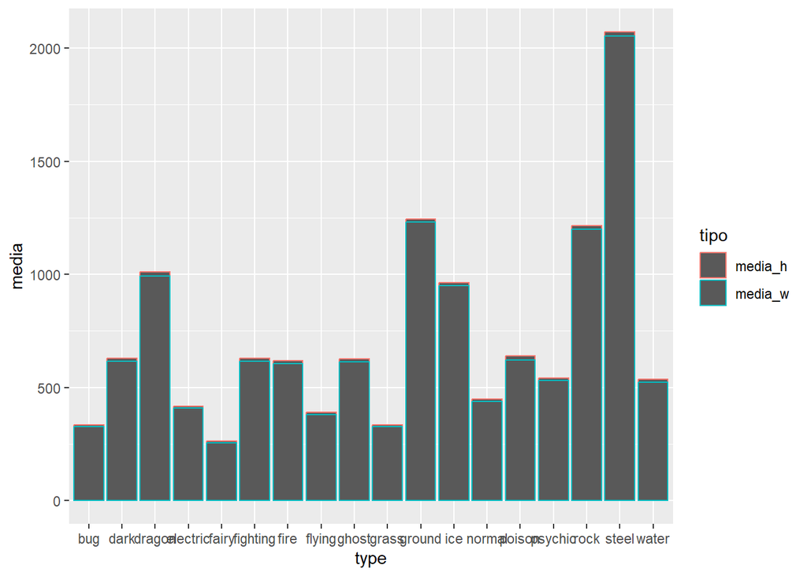

```r
#grafico da média da altura e do peso


dados %>%
  group_by(type) %>%
  summarise(
    media_h = mean(height),
    media_w = mean(weight)
  ) %>%
  tidyr::pivot_longer(cols = c("media_h", "media_w"), names_to = "tipo", values_to = "media") %>%
  ggplot()+
    geom_col(aes(x = type, y = media, color = tipo))
```

```r
# arrumar o gráfico
```

## Segundo eixo

É possível adicionar um segundo eixo. Precisamos achar um fator de escala

```r
# LIÇÃO 01/06

df <- dados %>%
  group_by(type) %>%
  summarise(
    media_h = mean(height),
    media_w = mean(weight)
  )

fator <- max(df$media_w)/max(df$media_h)
fator
```

```
## [1] 107.6608
```

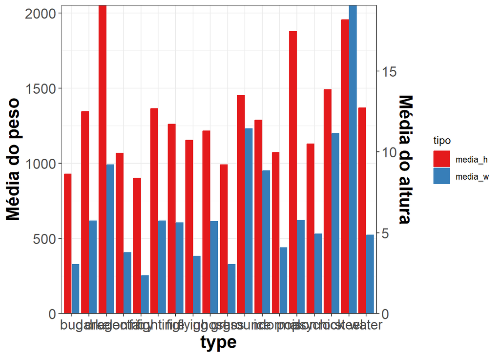

```r
df$media_h <- df$media_h*fator

df %>%
  tidyr::pivot_longer(cols = c("media_h", "media_w"), names_to = "tipo", values_to = "media") %>%
  ggplot()+
    geom_col(aes(x = type, y = media, color = tipo, fill = tipo), position = position_dodge2())+
  scale_y_continuous(

    # Features of the first axis
    name = "Média do peso",

    # Add a second axis and specify its features
    sec.axis = sec_axis(~./fator, name="Média do altura"),
    expand = c(0,0)
  )+
  scale_color_brewer(palette = "Set1")+
  scale_fill_brewer(palette = "Set1")+
  theme_bw()+
  theme(
    axis.title = element_text(size = 18, face = "bold"),
    axis.text = element_text(size = 14)
  )
```

```r
# TODO arrumar
```

## Mais plots

```r
df <- dados %>%
  group_by(type) %>%
  summarise(
    media_h = mean(height),
    media_w = mean(weight),
    sd_h = sd(height),
    sd_w = sd(weight)
  )

fator <- max(df$media_w)/max(df$media_h)
fator
```

```
## [1] 107.6608
```

```r
df$sd_h <- df$sd_h*fator
df$media_h <- df$media_h*fator


df_media <- df %>%
  select(type, media_h, media_w) %>%
  tidyr::pivot_longer(cols = c("media_h", "media_w"), names_to = "tipo", values_to = "media") %>%
  mutate(
    tipo = ifelse(tipo == "media_h", "Altura", "Peso")
  )


df_sd <- df %>%
  select(type, sd_h, sd_w) %>%
  tidyr::pivot_longer(cols = c("sd_h", "sd_w"), names_to = "tipo", values_to = "sd") %>%
  mutate(
    tipo = ifelse(tipo == "sd_h", "Altura", "Peso")
  )

df <- inner_join(df_media, df_sd, by = c("type", "tipo"))
df
```

```
## # A tibble: 36 × 4
##    type     tipo   media    sd
##    <chr>    <chr>  <dbl> <dbl>
##  1 bug      Altura  930.  589.
##  2 bug      Peso    327.  521.
##  3 dark     Altura 1344. 1267.
##  4 dark     Peso    616. 1496.
##  5 dragon   Altura 2053. 1564.
##  6 dragon   Peso    992. 1064.
##  7 electric Altura 1068.  770.
##  8 electric Peso    408.  502.
##  9 fairy    Altura  902.  872.
## 10 fairy    Peso    255.  506.
## # … with 26 more rows
```

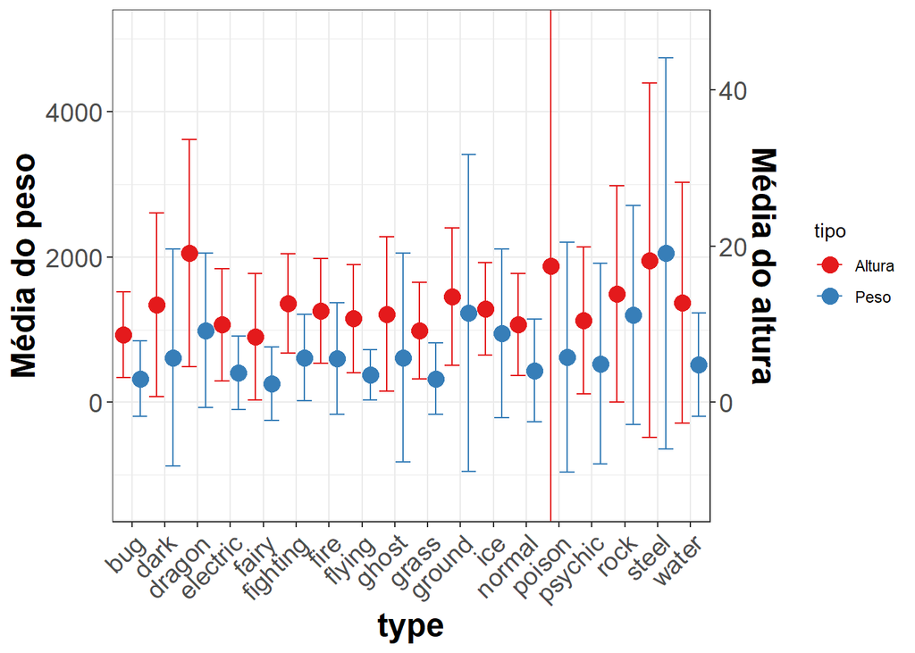

```r
  ggplot(df)+
    geom_point(aes(x = type, y = media, color = tipo, fill = tipo), position = position_dodge(1.0), size = 4)+
    geom_errorbar(aes(x = type, y = media, ymin = media-sd, ymax = media+sd, color = tipo, fill = tipo), position = position_dodge(1.0))+
  scale_y_continuous(

    # Features of the first axis
    name = "Média do peso",

    # Add a second axis and specify its features
    sec.axis = sec_axis(~./fator, name="Média do altura"),
    expand = c(0,0)
  )+
  scale_color_brewer(palette = "Set1")+
  scale_fill_brewer(palette = "Set1")+
  theme_bw()+
  theme(
    axis.title = element_text(size = 18, face = "bold"),
    axis.text.y = element_text(size = 14),
    axis.text.x = element_text(size = 14, angle = 45, hjust = 1.0)
  )
```

```r
df <- dados %>%
  group_by(type) %>%
  summarise(
    media_h = mean(height),
    media_w = mean(weight),
    sd_h = sd(height),
    sd_w = sd(weight)
  )

fator <- max(df$media_w)/max(df$media_h)
fator
```

```
## [1] 107.6608
```

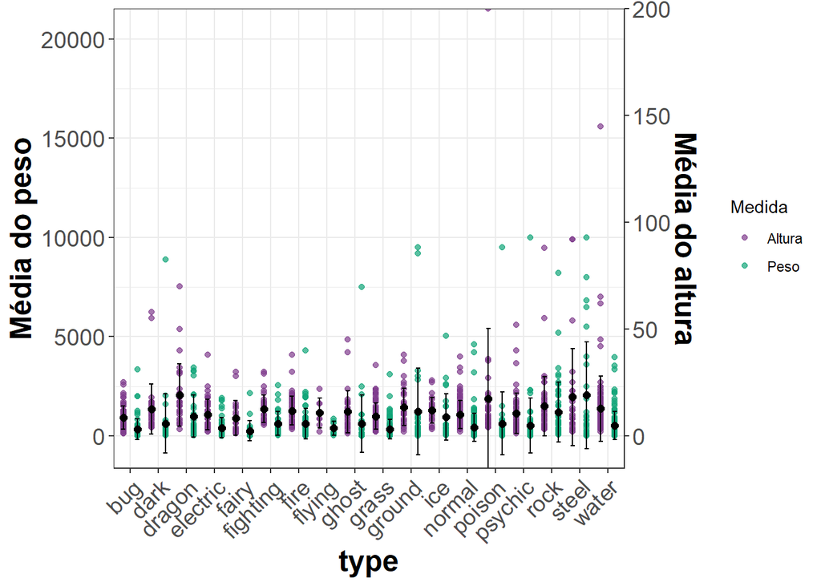

```r
df$sd_h <- df$sd_h*fator
df$media_h <- df$media_h*fator


df_media <- df %>%
  select(type, media_h, media_w) %>%
  tidyr::pivot_longer(cols = c("media_h", "media_w"), names_to = "tipo", values_to = "media") %>%
  mutate(
    tipo = ifelse(tipo == "media_h", "Altura", "Peso")
  )


df_sd <- df %>%
  select(type, sd_h, sd_w) %>%
  tidyr::pivot_longer(cols = c("sd_h", "sd_w"), names_to = "tipo", values_to = "sd") %>%
  mutate(
    tipo = ifelse(tipo == "sd_h", "Altura", "Peso")
  )

df <- inner_join(df_media, df_sd, by = c("type", "tipo"))


dados2 <- dados %>%
  select(type, Altura = height, Peso = weight)%>%
  mutate(
    Altura = Altura*fator
  ) %>%
  tidyr::pivot_longer(cols = c("Altura", "Peso"), names_to = "tipo", values_to = "valor")

cores <- rcartocolor::carto_pal(12, "Bold")

  ggplot()+
    geom_jitter(data = dados2, aes(x = type, y = valor, color = tipo, group = tipo), position = position_dodge(1.0), alpha = 0.7)+
    geom_point(data = df, aes(x = type, y = media, group = tipo), position = position_dodge(1.0), size = 2)+
    geom_errorbar(data = df, aes(x = type, y = media, ymin = media-sd, ymax = media+sd, group = tipo), position = position_dodge(1.0), width = 0.3)+
  scale_y_continuous(
    # Features of the first axis
    name = "Média do peso",

    # Add a second axis and specify its features
    sec.axis = sec_axis(~./fator, name="Média do altura"),
    expand = c(0,0)
  )+
  scale_color_manual(values = cores[1:2], name = "Medida")+
  scale_fill_manual(values = cores[1:2], name = "Medida")+
  theme_bw()+
  theme(
    axis.title = element_text(size = 18, face = "bold"),
    axis.text.y = element_text(size = 14),
    axis.text.x = element_text(size = 14, angle = 45, hjust = 1.0)
  )
```

## Plots legais

[Clique aqui](https://www.cedricscherer.com/2021/06/06/visualizing-distributions-with-raincloud-plots-and-how-to-create-them-with-ggplot2/)